# Prediction of student high school performance considering demographic and social features

STAT 420: Data Analysis Project - Summer 2019

2019-08-03 | Maximilian Trumpf (mtrumpf2), Rafal Tytyk (rtytyk2)

# Introduction

## Goal and motivation

The main goal of this project is to build a model which is capable of predicting student performance based on demographic and social features. In order to achieve this, we will use a dataset of student performances in secondary education in two Portugese schools (see Data chapter for details and introduction to the dataset).

The dataset contains many predictors which were collected using a consistent method (surveys and school reports) in a certain context (two defined Portugese schools in 2008). Therefore, the regression model being built will not be well fit for predicting student performance in a different context and with predictors being collected even with a slightly adjusted method. However, the primary goal of the regression model is **to explain the relationship of demographic and social features for student performance**.

This regression model based explanation is of personal motivation for the authors of this report since they are both fathers themselves and are interested in learning how to give a supportive environment for their children (although this analysis can of course only cover a very specialized tiny part and should not be understand as an extensive study of how to support children during high school).

## Data

### Overview

This analysis will use the *“Student Performance”* dataset. The dataset documents student performances in secondary education in two Portugese schools.

The original data provides two datasets covering two distinct subjects: Mathematics (**395 observations**) and Portugese (**649 observations**). Both datasets include the exact same set of attributes (**33 attributes**, see table below). When merging the two datasets, one will find **382 observations/students** who are present in the data and have taken both courses. (Merged based on `"school", "sex", "age", "address", "famsize", "Pstatus", "Medu", "Fedu", "Mjob", "Fjob", "reason", "nursery", "internet"`). Since this large overlap would impact the regression significantly (same students in both datasets), the model will primarily be fit on the larger `Portugese` dataset.

### Attributes

The main attributes to be used are the following:

- Main response: **G1 - first period grade, G2 - second period grade, G3 - final grade** (We will explore which of these is to be used as main response. We also suspect a high multicollinearity, so we will only include one of these and exclude the others as predictors.)
- Main predictors (hypothesis, to be validated)
  - **Sex** (categorial)
  - **Age** (numeric)
  - **Time spend with various activites** (numeric from 1 to 5; see full list of activites below)
  - **Parents’ education** (numeric from 1 to 4)

The full list of attributes can be found in the following table:

| Id | Name | Description |
| --- | --- | --- |
| 1 | school | student’s school (binary: ‘GP’ - Gabriel Pereira or ‘MS’ - Mousinho da Silveira) |
| 2 | sex | student’s sex (binary: ‘F’ - female or ‘M’ - male) |
| 3 | age | student’s age (numeric: from 15 to 22) |
| 4 | address | student’s home address type (binary: ‘U’ - urban or ‘R’ - rural) |
| 5 | famsize | family size (binary: ‘LE3’ - less or equal to 3 or ‘GT3’ - greater than 3) |
| 6 | Pstatus | parent’s cohabitation status (binary: ‘T’ - living together or ‘A’ - apart) |
| 7 | Medu | mother’s education (numeric: 0 - none, 1 - primary education (4th grade), 2 - 5th to 9th grade, 3 - secondary education or 4 - higher education) |
| 8 | Fedu | father’s education (numeric: 0 - none, 1 - primary education (4th grade), 2 - 5th to 9th grade, 3 - secondary education or 4 - higher education) |
| 9 | Mjob | mother’s job (nominal: ‘teacher’, ‘health’ care related, civil ‘services’ (e.g. administrative or police), ‘at_home’ or ‘other’) |
| 10 | Fjob | father’s job (nominal: ‘teacher’, ‘health’ care related, civil ‘services’ (e.g. administrative or police), ‘at_home’ or ‘other’) |
| 11 | reason | reason to choose this school (nominal: close to ‘home’, school ‘reputation’, ‘course’ preference or ‘other’) |
| 12 | guardian | student’s guardian (nominal: ‘mother’, ‘father’ or ‘other’) |
| 13 | traveltime | home to school travel time (numeric: 1 - 1 hour) |
| 14 | studytime | weekly study time (numeric: 1 - 10 hours) |
| 15 | failures | number of past class failures (numeric: n if 1<=n<3, else 4) |
| 16 | schoolsup | extra educational support (binary: yes or no) |
| 17 | famsup | family educational support (binary: yes or no) |
| 18 | paid | extra paid classes within the course subject (Math or Portuguese) (binary: yes or no) |
| 19 | activities | extra-curricular activities (binary: yes or no) |
| 20 | nursery | attended nursery school (binary: yes or no) |
| 21 | higher | wants to take higher education (binary: yes or no) |
| 22 | internet | Internet access at home (binary: yes or no) |
| 23 | romantic | with a romantic relationship (binary: yes or no) |
| 24 | famrel | quality of family relationships (numeric: from 1 - very bad to 5 - excellent) |
| 25 | freetime | free time after school (numeric: from 1 - very low to 5 - very high) |
| 26 | goout | going out with friends (numeric: from 1 - very low to 5 - very high) |
| 27 | Dalc | workday alcohol consumption (numeric: from 1 - very low to 5 - very high) |
| 28 | Walc | weekend alcohol consumption (numeric: from 1 - very low to 5 - very high) |
| 29 | health | current health status (numeric: from 1 - very bad to 5 - very good) |
| 30 | absences | number of school absences (numeric: from 0 to 93) |
| 31 | G1 | first period grade (numeric: from 0 to 20) |
| 32 | G2 | second period grade (numeric: from 0 to 20) |
| 33 | G3 | final grade (numeric: from 0 to 20) |

### Background information

The data was collected by using school reports and questionnaries.

The data was accessed on 2019-07-02 via [UCI Machine Learning Repository/Student Performance](http://archive.ics.uci.edu/ml/datasets/Student+Performance#).

The dataset was collected by Paulo Cortez, University of Minho, GuimarÃ£es, Portugal, http://www3.dsi.uminho.pt/pcortez.

# Methods

## Data preparation

First we will load the data

```r
student = read.csv("data/student-por.csv", header = TRUE, sep = ";")
head(student)
```

```
##   school sex age address famsize Pstatus Medu Fedu     Mjob     Fjob
## 1     GP   F  18       U     GT3       A    4    4  at_home  teacher
## 2     GP   F  17       U     GT3       T    1    1  at_home    other
## 3     GP   F  15       U     LE3       T    1    1  at_home    other
## 4     GP   F  15       U     GT3       T    4    2   health services
## 5     GP   F  16       U     GT3       T    3    3    other    other
## 6     GP   M  16       U     LE3       T    4    3 services    other
##       reason guardian traveltime studytime failures schoolsup famsup paid
## 1     course   mother          2         2        0       yes     no   no
## 2     course   father          1         2        0        no    yes   no
## 3      other   mother          1         2        0       yes     no   no
## 4       home   mother          1         3        0        no    yes   no
## 5       home   father          1         2        0        no    yes   no
## 6 reputation   mother          1         2        0        no    yes   no
##   activities nursery higher internet romantic famrel freetime goout Dalc
## 1         no     yes    yes       no       no      4        3     4    1
## 2         no      no    yes      yes       no      5        3     3    1
## 3         no     yes    yes      yes       no      4        3     2    2
## 4        yes     yes    yes      yes      yes      3        2     2    1
## 5         no     yes    yes       no       no      4        3     2    1
## 6        yes     yes    yes      yes       no      5        4     2    1
##   Walc health absences G1 G2 G3
## 1    1      3        4  0 11 11
## 2    1      3        2  9 11 11
## 3    3      3        6 12 13 12
## 4    1      5        0 14 14 14
## 5    2      5        0 11 13 13
## 6    2      5        6 12 12 13
```

Check whether we have any missing values

```r
any(is.na(student))
```

```
## [1] FALSE
```

No missing values, so continue as is.

Validate that the attributes have the desired types

```r
str(student)
```

```
## 'data.frame':    649 obs. of  33 variables:
##  $ school    : Factor w/ 2 levels "GP","MS": 1 1 1 1 1 1 1 1 1 1 ...
##  $ sex       : Factor w/ 2 levels "F","M": 1 1 1 1 1 2 2 1 2 2 ...
##  $ age       : int  18 17 15 15 16 16 16 17 15 15 ...
##  $ address   : Factor w/ 2 levels "R","U": 2 2 2 2 2 2 2 2 2 2 ...
##  $ famsize   : Factor w/ 2 levels "GT3","LE3": 1 1 2 1 1 2 2 1 2 1 ...
##  $ Pstatus   : Factor w/ 2 levels "A","T": 1 2 2 2 2 2 2 1 1 2 ...
##  $ Medu      : int  4 1 1 4 3 4 2 4 3 3 ...
##  $ Fedu      : int  4 1 1 2 3 3 2 4 2 4 ...
##  $ Mjob      : Factor w/ 5 levels "at_home","health",..: 1 1 1 2 3 4 3 3 4 3 ...
##  $ Fjob      : Factor w/ 5 levels "at_home","health",..: 5 3 3 4 3 3 3 5 3 3 ...
##  $ reason    : Factor w/ 4 levels "course","home",..: 1 1 3 2 2 4 2 2 2 2 ...
##  $ guardian  : Factor w/ 3 levels "father","mother",..: 2 1 2 2 1 2 2 2 2 2 ...
##  $ traveltime: int  2 1 1 1 1 1 1 2 1 1 ...
##  $ studytime : int  2 2 2 3 2 2 2 2 2 2 ...
```

[output cut: 19 more lines]

There are two important observations from the structure of the data:

1. Various attributes are clearly categorial predictors (e.g., `romantic (yes, no)`). They were already correctly captured as `factors` during data import, so no further action needed.
2. Some attributes could either be modeled as categorial or as numeric predictors (e.g., `traveltime`, `studytime`).

For now we will:

## Data correlation

Evaluate correlation

```r
# Evaluate correlation
cor_matrix = cor(student[, sapply(student, is.numeric)])
which( cor_matrix > 0.7 & cor_matrix < 1.0, arr.ind = T)
```

```
##    row col
## G2  15  14
## G3  16  14
## G1  14  15
## G3  16  15
## G1  14  16
## G2  15  16
```

## Linear Regression Analysis

### Evaluation of distribution of response variable `G3`

Visualize distribution of response attribute `G3`

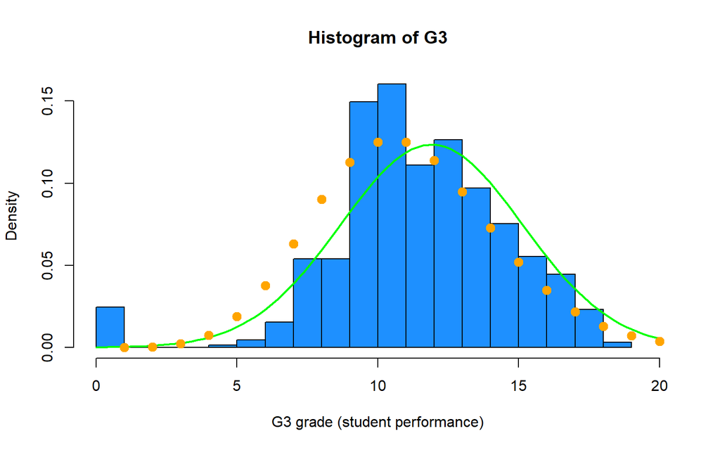

From a visual inspection, the response could either follow a normal (green curve) or a Poisson distribution (orange points). Since there is not a large delta of the “fit”, we will primarily be using **Linear Regression Models** over **Generalized Linear Models with link function for Poisson distribution**. This will allow for easier interpretation.

### Data Split

We’ll split our dataset into train/test sets:

```r
set.seed(42, sample.kind = "Rounding")
trn_idx = sample(nrow(student), round(nrow(student)*.8))
student_trn = student[trn_idx, ]
student_tst = student[-trn_idx, ]
```

### Linear regression

#### Diagnostics

We will provide a set of functions for diagnostics of the to be developed models:

```r
accuracy = function(model) {
  mean(round(predict(model, newdata = student_tst)) == student_tst$G3)
}

loocv_rmse = function(model) {
  sqrt(mean((resid(model) / (1 - hatvalues(model))) ^ 2))
}

influence = function(model, alpha = 0.01) {
  model_coef = summary(model)$coefficients
  model_coef[model_coef[,"Pr(>|t|)"] < alpha, "Pr(>|t|)"]
}
```

Let’s find the accuracy baseline, which we will try to beat:

```r
baseline_mod = lm(G3 ~ 1, data = student_trn)
coef(baseline_mod)[[1]]
```

```
## [1] 11.91908
```

Our baseline model would always predict `G3 =` `11.9190751`.

```r
accuracy(baseline_mod)
```

```
## [1] 0.1307692
```

The baseline model would get an accuracy score of `0.1307692`, which we will try to beat.

#### Initial model evaluation

Now we’ll build full additive model. We will use p-values ($\alpha=0.01$) to identify signifcant predictors and build a smaller model:

```r
full_add_mod = lm(G3 ~ ., data = student_trn)
influence(full_add_mod)
```

```
##     failures           G1           G2
## 2.599541e-04 1.496760e-03 1.324223e-69
```

As expected, we’re finding `G2` and `G1` as being very influential as well as `failures`. As we already expected that past performances are the major predictor for future performances, we will work with a model without `G1` and `G2`:

```r
large_add_mod = lm(G3 ~ . - G2 - G1, data = student_trn)
influence(large_add_mod)
```

```
##  (Intercept)     schoolMS    studytime     failures    higheryes
## 1.378667e-03 3.470548e-03 8.457433e-03 4.724540e-11 2.847770e-04
##  romanticyes
## 9.238577e-03
```

We’re discovering `school`, `studytime`, `failures`, `higher` and `romantic` are being the most influential predictors, rejecting null hypothesis for any reasonable $\alpha$ level. Let’s build a model out of those predictors:

```r
small_add_mod = lm(G3 ~ school + studytime + failures + higher + romantic, data = student_trn)
coef(small_add_mod)
```

```
## (Intercept)    schoolMS   studytime    failures   higheryes romanticyes
##  10.0591379  -1.2980092   0.6081321  -1.5536191   1.8790184  -0.4259098
```

And compare it to the full additive model that has `G2` and `G1` removed:

```r
anova(large_add_mod, small_add_mod)$`Pr(>F)`[2]
```

```
## [1] 0.005415537
```

We reject the null hypothesis at $\alpha = 0.05$ and $\alpha = 0.01$. The more complex model performs better.

But let’s also check how the models perform on unseen data:

```r
perf = data.frame(c(accuracy(full_add_mod), accuracy(large_add_mod), accuracy(small_add_mod)),
                  c(loocv_rmse(full_add_mod), loocv_rmse(large_add_mod), loocv_rmse(small_add_mod)))
colnames(perf) = c("Accuracy on test set", "LOOCV RMSE")
row.names(perf) = c("Full additive model (incl. G1 and G2)", "Large additive model (excl. G1 and G2)", "Small additive model")
perf
```

```
##                                        Accuracy on test set LOOCV RMSE
## Full additive model (incl. G1 and G2)             0.4076923   1.333630
## Large additive model (excl. G1 and G2)            0.1923077   2.804944
## Small additive model                              0.1769231   2.767544
```

All models are above the accuracy baseline of `0.1307692`.

We will continue our search based on the large additive model and based on the full additive model.

Let’s start searching for a better model using `AIC` based on the large additive model:

```r
scope = formula(lm(G3 ~ (. - G1 - G2) ^ 3, data = student_trn))
int_mod_large_AIC = step(small_add_mod, scope = scope, direction = "forward", trace = 0)
```

```r
accuracy(int_mod_large_AIC)
```

```
## [1] 0.1384615
```

```r
loocv_rmse(int_mod_large_AIC)
```

```
## [1] 2.540672
```

Using `AIC` we get a model which does not well perform on unseen data (ie overfitting), we will therefore switch to `BIC`.

```r
n = nrow(student_trn)
scope = formula(lm(G3 ~ (. - G1 - G2) ^ 3, data = student_trn))
int_mod_large_BIC = step(small_add_mod, scope = scope, direction = "forward", trace = 0, k = log(n))
```

```r
accuracy(int_mod_large_BIC)
```

```
## [1] 0.2384615
```

```r
loocv_rmse(int_mod_large_BIC)
```

```
## [1] 2.716821
```

We were able to improve our accuracy from `0.1923077` to `0.2384615`.

Based on the improved model, we will also try to do a polynomial transformation:

```r
int_pol_mod_large = lm(G3 ~ school + studytime + I(studytime ^ 2) + failures + I(failures ^ 2) + higher + romantic + Medu + I(Medu ^ 2) + sex + schoolsup, data = student_trn)
```

Let’s only keep terms with a reasonable low p-value first:

```r
int_pol_mod_large = lm (G3 ~ school + studytime + failures + I(failures ^ 2) + higher + I(Medu ^ 2) + sex + schoolsup, data = student_trn)
```

```r
accuracy(int_pol_mod_large)
```

```
## [1] 0.2076923
```

```r
loocv_rmse(int_pol_mod_large)
```

```
## [1] 2.69767
```

The polynomial transformation did not deliver an improvement on unseen data for the large model (excl. `G1` and `G2`). So we will keep the additive model selected using $BIC$ as our *best* model (`int_mod_large_BIC`).

Now let’s do the same thing with the full model (including `G1` and `G2`). We will right away start with `BIC` so to avoid overfitting (which we have seen before when using `AIC`):

```r
n = nrow(student_trn)
scope = formula(lm(G3 ~ (.) ^ 3, data = student_trn))
int_mod_full_BIC = step(small_add_mod, scope = scope, direction = "forward", trace = 0, k = log(n))
```

```r
accuracy(int_mod_full_BIC)
```

```
## [1] 0.4923077
```

```r
loocv_rmse(int_mod_full_BIC)
```

```
## [1] 1.286076
```

We were able to improve our accuracy from `0.4076923` to `0.4923077`.

Based on the improved model, we will also try to do a polynomial transformation:

```r
int_pol_mod_full = lm(G3 ~ school + I(studytime ^ 2) + I(failures ^ 2) + I(G2 ^ 2) + I(G1 ^ 2) + higher + romantic + higher:romantic + G2:G1, data = student_trn)
```

```r
accuracy(int_pol_mod_full)
```

```
## [1] 0.5076923
```

```r
loocv_rmse(int_pol_mod_full)
```

```
## [1] 1.554996
```

This could further increase our accuracy from `0.4923077` to `0.5076923`.

#### Regression diagnostics

Based on the best initial models, we will perform regression diagnostics to try to further improve performance.

We will start with the full interaction polynomial model.

At first let’s see whether we have influential observations:

```r
influential_obs_idx = cooks.distance(int_pol_mod_full) > 4 / length(cooks.distance(int_pol_mod_full))
sum(influential_obs_idx)
```

```
## [1] 27
```

We will remove these `27` observations.

```r
student_trn_cleaned = student_trn[!influential_obs_idx, ]
```

```r
int_pol_mod_full_cleaned = lm(G3 ~ school + I(studytime ^ 2) + I(failures ^ 2) + I(G2 ^ 2) + I(G1 ^ 2) + higher + romantic + higher:romantic + G2:G1, data = student_trn_cleaned)
```

```r
accuracy(int_pol_mod_full_cleaned)
```

```
## [1] 0.4769231
```

```r
loocv_rmse(int_pol_mod_full_cleaned)
```

```
## [1] 0.8477408
```

We were not able to improve the performance.

Let’s try the same thing on our large model (excl. `G1` and `G2`).

```r
influential_obs_idx = cooks.distance(int_mod_large_BIC) > 4 / length(cooks.distance(int_mod_large_BIC))
sum(influential_obs_idx)
```

```
## [1] 27
```

We will remove these `27` observations.

```r
student_trn_cleaned = student_trn[!influential_obs_idx, ]
```

```r
int_mod_large_BIC_cleaned = lm(formula = G3 ~ school + studytime + failures + higher + romantic +
    Medu + sex + schoolsup, data = student_trn_cleaned)
```

```r
accuracy(int_mod_large_BIC_cleaned)
```

```
## [1] 0.2230769
```

```r
loocv_rmse(int_mod_large_BIC_cleaned)
```

```
## [1] 2.07478
```

For this model, the removal of unusual observations did also not lead to a performance increase.

Let’s also take a look at fitted-vs-residuals and QQ-plot. At first we will define a `diagnostics` function, which will (1) plot fitted-vs-residuals plot, (2) plot qq-plot, (3) calculate sw-test, (4) calcualted bp-test. (function will not be knitted to html)

```r
library(lmtest)

diagnostics = function(model, pcol = "grey", lcol = "dodgerblue", alpha = 0.05, plotit = TRUE, testit = TRUE) {
  if (plotit == TRUE) {
    par(mfrow = c(1, 2))

    # Fitted vs residuals plot
    plot(fitted(model), resid(model),
         col = pcol,
         pch = 20,
         xlab = "Fitted",
         ylab = "Residuals",
         main = "Fitted vs residuals plot")
    abline(h = 0,
           col = lcol,
           lwd = 2)

    # QQ-plot
    qqnorm(resid(model),
           main = "Normal Q-Q Plot",
           col = pcol)
    qqline(resid(model),
           col = lcol,
           lwd = 2)
  }
  if (testit == TRUE) {
    p_sw = shapiro.test(resid(model))$p.value
    if (p_sw < alpha) {
      decision_sw = "Reject | Data not sampled from normal"
    } else {
      decision_sw = "Fail to Reject | Data sampled from normal"
    }
    p_bp = bptest(model)$p.value
    if (p_bp < alpha) {
      decision_bp = "Reject | Question equal variance"
    } else {
      decision_bp = "Fail to Reject | Likely equal variance"
    }
    list("p_val_sw" = p_sw, "decision_sw" = decision_sw, "p_val_bp" = p_bp, "decision_bp" = decision_bp)
  }
}
```

Let’s analyse our so far best model:

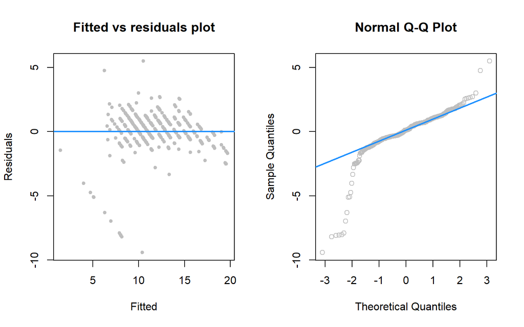

```
## $p_val_sw
## [1] 3.275784e-26
##
## $decision_sw
## [1] "Reject | Data not sampled from normal"
##
## $p_val_bp
##           BP
## 0.0002244786
##
## $decision_bp
## [1] "Reject | Question equal variance"
```

```r
diagnostics(int_pol_mod_full)
```

And also the cleaned version of our so far best model:

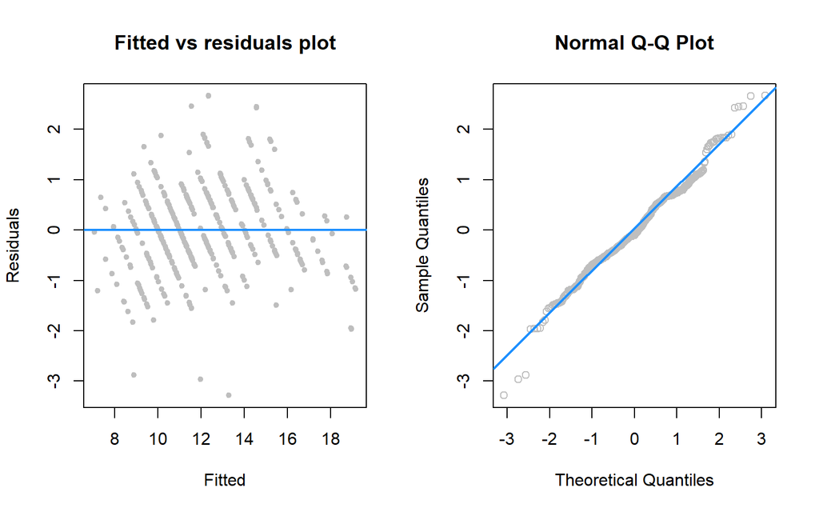

```
## $p_val_sw
## [1] 8.389492e-05
##
## $decision_sw
## [1] "Reject | Data not sampled from normal"
##
## $p_val_bp
##        BP
## 0.8862942
##
## $decision_bp
## [1] "Fail to Reject | Likely equal variance"
```

```r
diagnostics(int_pol_mod_full_cleaned)
```

# Results

We will start explaining the social and demographic impacts on student performance using *standard* statistical analysis before using our regression models for the explanation.

## Basic data overview

```
##  school   sex          age        address famsize   Pstatus
##  GP:423   F:383   Min.   :15.00   R:197   GT3:457   A: 80
##  MS:226   M:266   1st Qu.:16.00   U:452   LE3:192   T:569
##                   Median :17.00
##                   Mean   :16.74
##                   3rd Qu.:18.00
##                   Max.   :22.00
##       Medu            Fedu             Mjob           Fjob
##  Min.   :0.000   Min.   :0.000   at_home :135   at_home : 42
##  1st Qu.:2.000   1st Qu.:1.000   health  : 48   health  : 23
##  Median :2.000   Median :2.000   other   :258   other   :367
##  Mean   :2.515   Mean   :2.307   services:136   services:181
##  3rd Qu.:4.000   3rd Qu.:3.000   teacher : 72   teacher : 36
##  Max.   :4.000   Max.   :4.000
##         reason      guardian     traveltime      studytime
##  course    :285   father:153   Min.   :1.000   Min.   :1.000
##  home      :149   mother:455   1st Qu.:1.000   1st Qu.:1.000
##  other     : 72   other : 41   Median :1.000   Median :2.000
##  reputation:143                Mean   :1.569   Mean   :1.931
##                                3rd Qu.:2.000   3rd Qu.:2.000
##                                Max.   :4.000   Max.   :4.000
##     failures      schoolsup famsup     paid     activities nursery
##  Min.   :0.0000   no :581   no :251   no :610   no :334    no :128
##  1st Qu.:0.0000   yes: 68   yes:398   yes: 39   yes:315    yes:521
##  Median :0.0000
##  Mean   :0.2219
##  3rd Qu.:0.0000
##  Max.   :3.0000
##  higher    internet  romantic      famrel         freetime
##  no : 69   no :151   no :410   Min.   :1.000   Min.   :1.00
##  yes:580   yes:498   yes:239   1st Qu.:4.000   1st Qu.:3.00
##                                Median :4.000   Median :3.00
##                                Mean   :3.931   Mean   :3.18
##                                3rd Qu.:5.000   3rd Qu.:4.00
##                                Max.   :5.000   Max.   :5.00
##      goout            Dalc            Walc          health
##  Min.   :1.000   Min.   :1.000   Min.   :1.00   Min.   :1.000
##  1st Qu.:2.000   1st Qu.:1.000   1st Qu.:1.00   1st Qu.:2.000
##  Median :3.000   Median :1.000   Median :2.00   Median :4.000
##  Mean   :3.185   Mean   :1.502   Mean   :2.28   Mean   :3.536
##  3rd Qu.:4.000   3rd Qu.:2.000   3rd Qu.:3.00   3rd Qu.:5.000
##  Max.   :5.000   Max.   :5.000   Max.   :5.00   Max.   :5.000
##     absences            G1             G2              G3
##  Min.   : 0.000   Min.   : 0.0   Min.   : 0.00   Min.   : 0.00
##  1st Qu.: 0.000   1st Qu.:10.0   1st Qu.:10.00   1st Qu.:10.00
##  Median : 2.000   Median :11.0   Median :11.00   Median :12.00
##  Mean   : 3.659   Mean   :11.4   Mean   :11.57   Mean   :11.91
##  3rd Qu.: 6.000   3rd Qu.:13.0   3rd Qu.:13.00   3rd Qu.:14.00
##  Max.   :32.000   Max.   :19.0   Max.   :19.00   Max.   :19.00
```

There are *383 females* and *266 males* in the dataset. A strong majority of *457 to 192 have more than 2 siblings*. Majority of *410 to 239 aren’t in romantic relationships* and strong majority of *580 to 69 want higher education*. On average our students report *good health* and *good relationship* with their families. Strong majority of *455 to 194 have mother* as their guardian. Students go out 3 days a week on average, which is as much as they have free time. On average, they are absent from class 3.66 days, with one person being absent 32 days.

```
##     G1 G2 G3 absences sex age
## 151  9  8  9       24   F  15
## 156  9  7  6       22   M  17
## 198 14 13 14       32   F  17
## 213 14 15 16       30   F  17
## 218 13 13 13       21   F  17
## 257  7  8  8       26   M  18
## 326 11 11 10       22   M  17
## 414  9 10 10       21   M  21
```

### Best and worse students

Let’s start off by looking at best students, understood as those that scored higher than 17 on `G3`:

| Query | Best students | Worst students |
| --- | --- | --- |
| Average age | 17 | 17.94 |
| Average study time | 2.59 | 1.47 |
| How many had a paid tuition | 0 | 1 |
| Average health | 3.12 | 3.71 |
| Average drinking during the week | 1.24 | 2.18 |
| Average drinking during the weeekend | 1.71 | 2.88 |
| Average family relationship | 4 | 3.94 |
| Average free time | 2.82 | 3.65 |
| Average father’s education | 1.94 | 1.71 |
| Average mother’s education | 2.82 | 2.35 |

We observe that best students are on average younger, study more and drink less than their worst counterparts, they also tend to have less free time and report worse health. They also didn’t do any paid tuition.

### Guardian

Now we’ll look at `G3` performance based on student’s primary guardian:

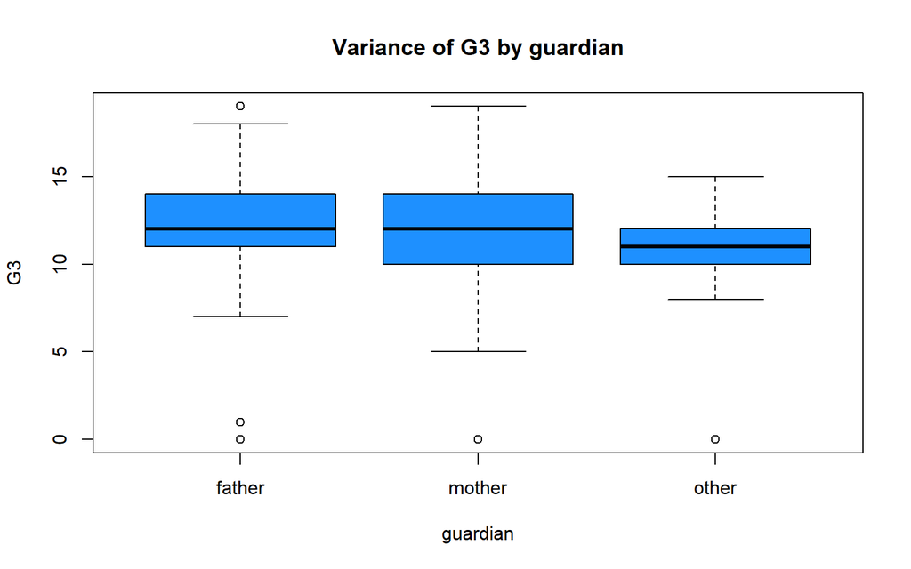

We observe that students who’s primary guardian is mother have broadest variance on both ends. Fathers tend to limit lower end at the cost of some higher end. Other types of guardians seem to do worse on average, having much smaller variance on both ends.

### Parents education

Now let’s see how parents’s education influences their children:

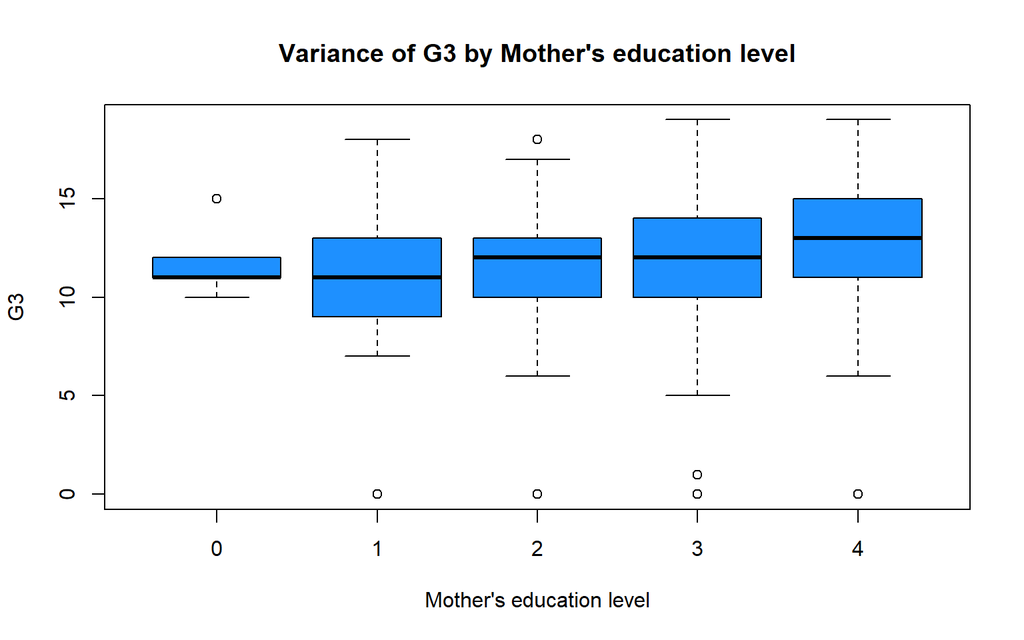

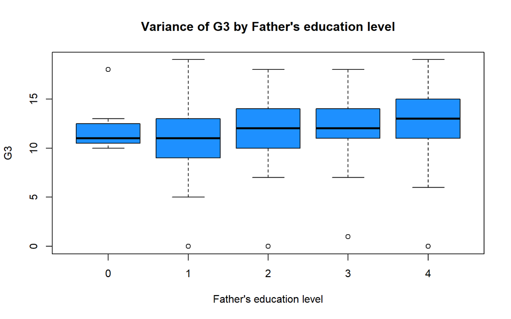

It can be observed that students who’s parents are highly educated do best on average, although there are similar levels of variations across the groups of 1+.

Students having at least one the parents uneducated do not get lower than 10 but also no higher than 13 points, with the exception of 2 students:

```
##     G1 G2 G3 age sex Medu    Mjob Fedu    Fjob paid activities
## 186 16 17 18  16   M    1   other    0   other   no        yes
## 376 14 14 15  17   F    0 at_home    2 at_home   no         no
```

### Health

Let’s visualize how healthy are our students:

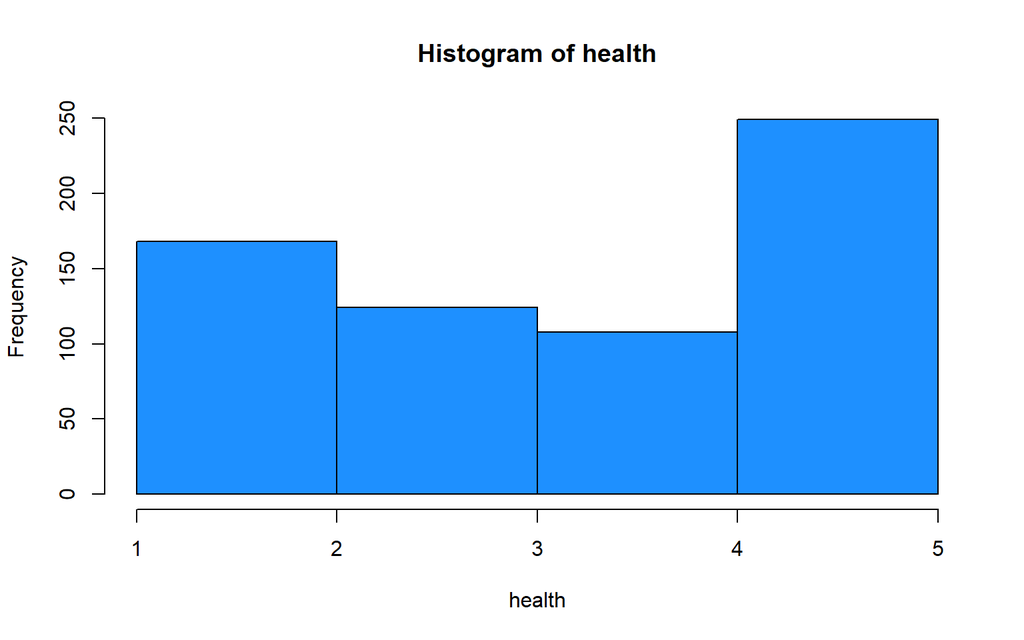

- 74.1140216% students report their health to be 3 and up,
- 25.8859784% students report health below 3.

Let’s visualize if health influences `G3` in significant way:

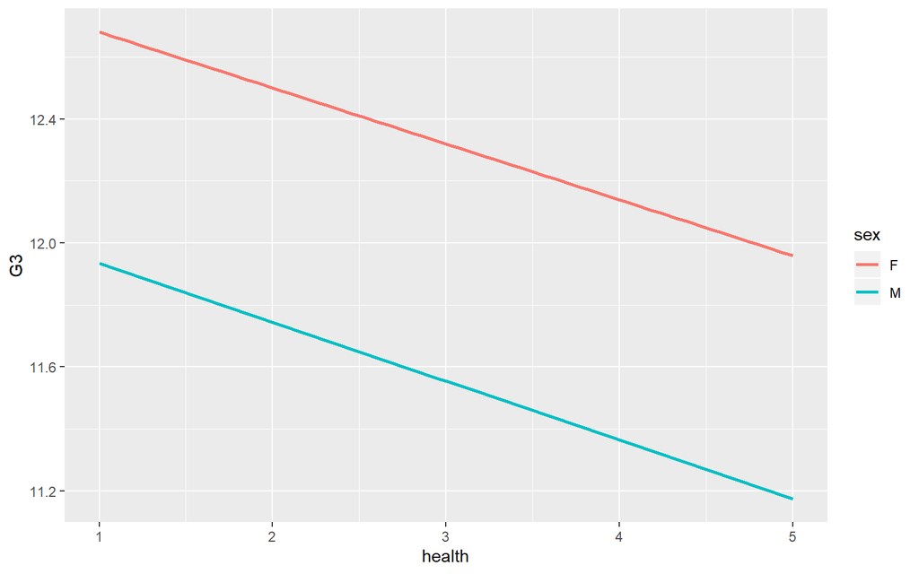

Strangely, we’re observing small, but inverse relationship between `health` and `G3`. Perhaps feeling good take students off their studying.

### Age

Let’s visualize relationship between `age`, `sex` and `G3`:

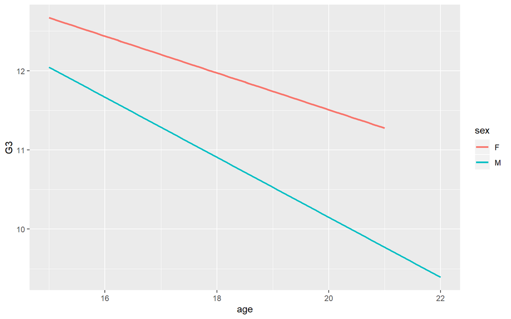

We notice inverse relationship between `age` and `G3` performance for both sexes. Females are doing on average better than males by $0.8472487$ points on `G3` and while no females over 21 are present in the dataset, there is 1 male student aged 22, doing the worst - a potential outlier:

```
##     sex age G1 G2 G3 higher failures studytime famsize
## 280   M  22  7  8  5     no        3         1     GT3
```

### Studytime, absences

Now let’s observe how `studytime` and `absences` affect `G3`. We’ll divide results by `sex`:

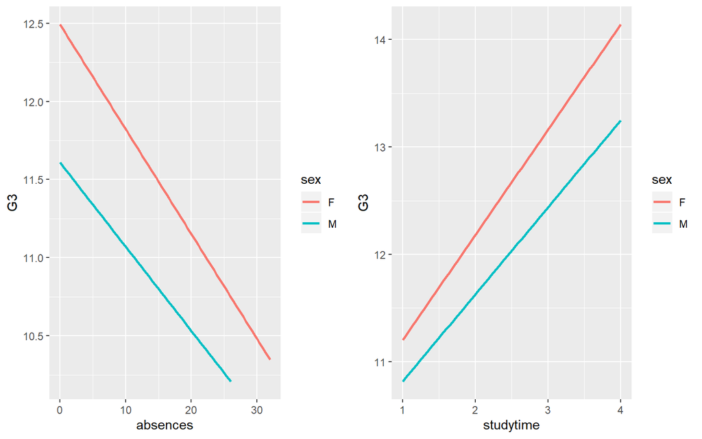

We’re seeing a positive relationship between `studytime` and `G3` result, greater by a point than the inverse relationship between `absences` and `G3`. We’d expect students that do study in their free time should do better even if they miss the school.

- Average of G3 based on absences:
  - Having 16 and more absences: 10.7619048,
  - Having less than 16 absences: 11.9442675,
- Average of G3 based on study time:
  - Studied 3/5 or more: 13.1818182,
  - Studied 2/5 or less: 11.5802708,

### Alkohol consumption and Activities

Now we’ll look how alkohol consumption affect `G3` performance. We’ll group the plots into people who take off-school `acivities` and those who do not.

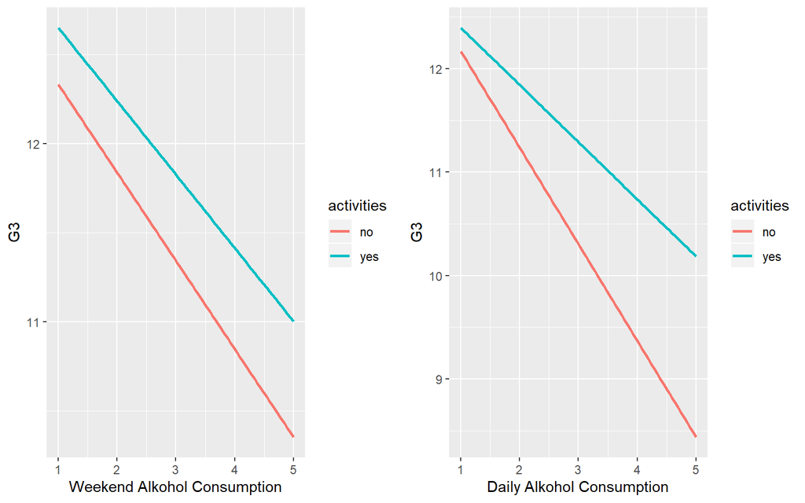

We can clearly observe that daily consumption of alkohol resolves in much worse performance than weekend consumption. The effect is made even larger by lack of `activities`, especially for people consuming alkohol daily.

Let’s look how much are students drinking:

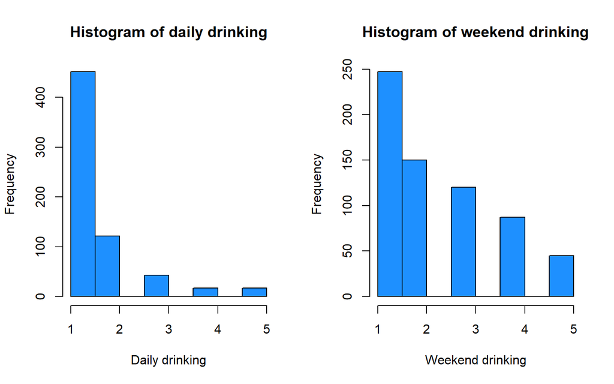

Good to know that vast majority of students drink very little or not at all, and the majority of weekend drinkers are also aiming for lowest possible levels of intoxication or at least they report so, although we’re seeing a lot more of weekend drinkers.

- No. of drinkers:
  - Light weekend drinkers: 397,
  - Heavy weekend drinkers: 252,
  - Light daily drinkers: 572,
  - Heavy daily drinkers: 77.

## Linear regression

### Prediction performance

The following table shows the **accuracy** on test data, $LOOCV-RMSE$ and $R^2$ of the best models we built and the baseline model (see Initial Model Evaluation) using linear regression:

|  | Accuracy on test data | LOOCV-RMSE | R-squared |
| --- | --- | --- | --- |
| Full (incl. G1 and G2) polynomial, interaction model | 0.508 | 1.555 | 0.799 |
| Large (excl. G1 and G2) additive model | 0.238 | 2.717 | 0.317 |
| Small additive model | 0.177 | 2.768 | 0.283 |
| Baseline model | 0.131 | 3.233 | 0.000 |

We will continue with the two best performing models from our two perspectives `Full (incl. G1 and G2)` and `Large (excl. G1 and G2)` (see discussion chapter for explanation of this distinction).

Let’s plot the actual vs. predicted G3 performance for our two best models.

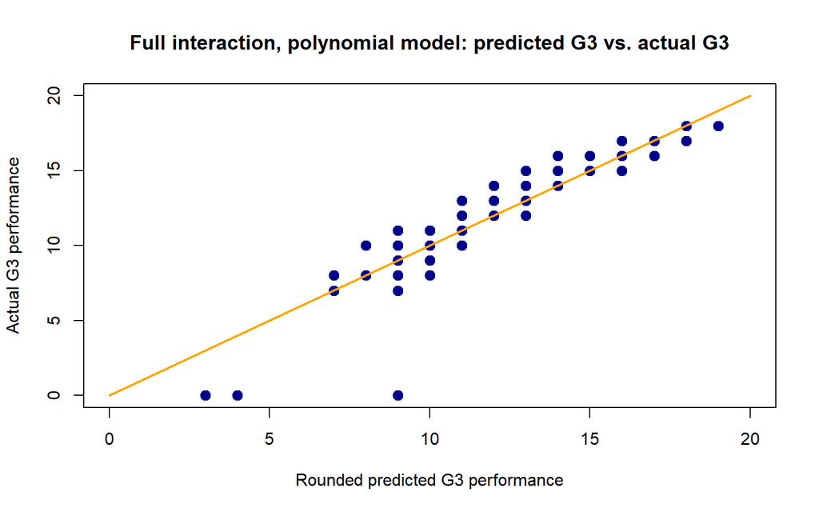

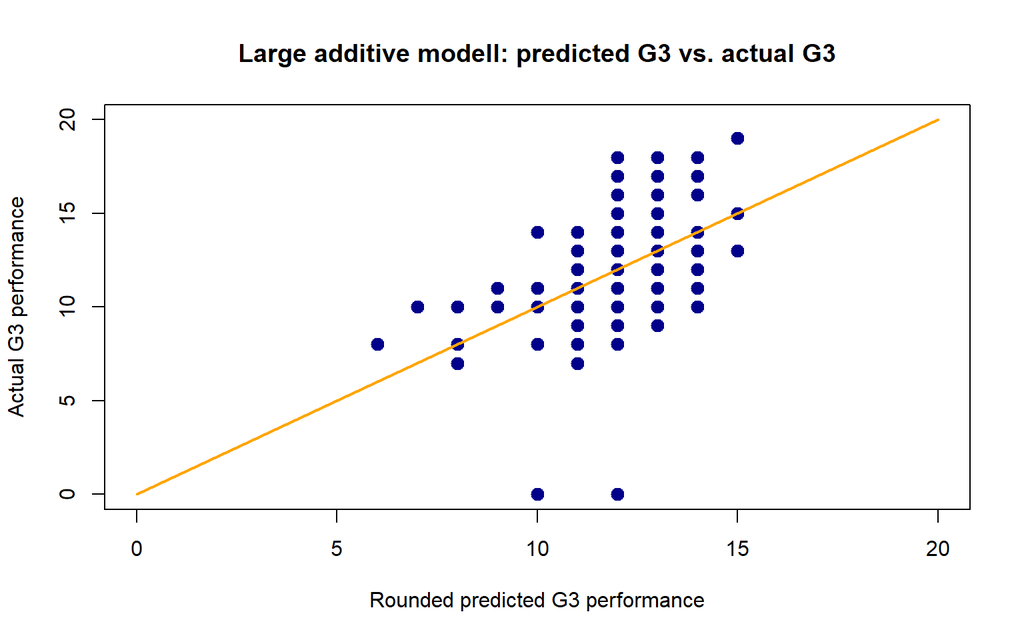

The plots show us:

1. For students with a performance of `0` in `G3`, both models perform the worst (although the full model is a bit better). So if a students completly fails `G3`, this is probably due to special circumstances.
2. The trend predicted by both models is correct. The large model not taking `G1` and `G2` into account, is not as precise as the full model but does still cover the trend correctly.

### Explaining the impact of social and demographic features on performance (`G3`) using the models

We will need the `estimate` as well as the `p-value` for explaining the impact of social and demographic features on performance. The discussions chapter will be used for the explanation.

For the full model:

|  | Estimate | Std. Error | t value | Pr(>\|t\|) |
| --- | --- | --- | --- | --- |
| (Intercept) | 6.27 | 0.32 | 19.41 | 0.00 |
| schoolMS | -0.44 | 0.14 | -3.15 | 0.00 |
| I(studytime^2) | 0.01 | 0.02 | 0.58 | 0.56 |
| I(failures^2) | -0.13 | 0.05 | -2.80 | 0.01 |
| I(G2^2) | 0.00 | 0.01 | -0.24 | 0.81 |
| I(G1^2) | -0.04 | 0.01 | -3.75 | 0.00 |
| higheryes | 0.23 | 0.31 | 0.75 | 0.46 |
| romanticyes | -0.74 | 0.39 | -1.89 | 0.06 |
| higheryes:romanticyes | 0.73 | 0.42 | 1.74 | 0.08 |
| G2:G1 | 0.08 | 0.02 | 4.24 | 0.00 |

And for the large model:

|  | Estimate | Std. Error | t value | Pr(>\|t\|) |
| --- | --- | --- | --- | --- |
| (Intercept) | 9.91 | 0.56 | 17.63 | 0.00 |
| schoolMS | -1.24 | 0.26 | -4.77 | 0.00 |
| studytime | 0.53 | 0.15 | 3.53 | 0.00 |
| failures | -1.47 | 0.21 | -6.93 | 0.00 |
| higheryes | 1.70 | 0.42 | 4.02 | 0.00 |
| romanticyes | -0.62 | 0.25 | -2.47 | 0.01 |
| Medu | 0.37 | 0.11 | 3.30 | 0.00 |
| sexM | -0.81 | 0.25 | -3.22 | 0.00 |
| schoolsupyes | -1.08 | 0.41 | -2.63 | 0.01 |

# Discussion

## Model selection

We are differentiating between `Full (incl. G1 and G2)` and `Large (excl. G1 and G2)` in the results. The reason for that is, that `G1` and `G2` have a high multicollinearity with the response `G3`. Also intuitively it makes sense that the past performance of a student is highly correlated with his/her future performance. Since our goal is to explain what social and demographic features impact future performance, we want to consider a model which therefore excludes `G1` and `G2` so that the other predictors can easier be used for interpretation.

The predicted vs. actual plots show us that:

- Both models can be used to explain how social and demographic features could impact the trend of the students performance.
- Special circumstances leading to `0` points can not be explained by the data.
- `G1` and `G2` are needed to more or lesss precisely estimate the grade (+/- ~3 points). Without them, the trend is still present, but the precision goes down (+/- ~6).

## Regression Model interpretation

While the full model `Full (incl. G1 and G2)` achieves an $R^2$ of `0.7989701`, the larger model `Large (excl. G1 and G2)` does only achieve an $R^2$ of `0.3171243`. So the model without `G1` and `G2` explains `0.3171243` of the variability in the data (which is `0.4818458` less than the model including `G1` and `G2`). This is what we intuitively would expect: **the most significant predictor for a student`s performance, is his or her past performance.**

However, still there are important social and demopgraphic features affecting the performance. In order to **perform this explanation, we will choose the coefficients from the simpler model (`Large (excl. G1 and G2)`)**, since the smaller model will allow for an easier interpration of the results.

There are 5 categorial and 3 numerical predictor attributes impacting the response variable performance `G3`.

- Categorial predictors
  - `school`: the `G3` performance will differ on average by `-1.2369907` if a student visits the `Mousinho da Silveira` school as compared to the `Gabriel Pereira` school.
  - `higher`: the `G3` performance will differ on average by `1.6989188` if a student aims for higher education as compared to if she/he doesn’t aim for higher education.
  - `romantic`: the `G3` performance will differ on average by `-0.6200089` if a student considers himself or herself as romantic (as compared to a non-romantic student).
  - `sex`: the `G3` performance will differ on average by `-0.8106863` if a student is male.
  - `schoolsup`: the `G3` performance will differ on average by `-1.0755406` if a student receives extra educational support.
- Numerical predictors
  - `studytime`: the `G3` performance will increase on average by `0.5308859` for increasing the study time by one hour per week for a student with a certain set of attributes (see other predictors of this model).
  - `failures`: the `G3` performance will decrease on average by `1.4731704` if a student with a certain set of attributes (see other predictors of this model) had 1 more past class failures.
  - `medu`: the `G3` performance will increase on average by `0.3706612` if the mother of a student with a certain set of attributes (see other predictors of this model) has 1 “level” (very low, low, …) more education.

**Interpretation of the results**

We can distinguish 3 different areas impacting the performance:

**Past performances**

Intuitively, the results make sense: if a student has had general difficulties in the past (indicated by `failures` and `schoolsup`), unfortunetly also his/her future performances will, according to the model, be lower as compared to a student who didn’t have such difficulties.

**Student motivation**

However, besides the past performance, one can positively influence the future performance: choose a school of high quality or which is simply giving better grades (differenciating this would need a separate analysis) (indicated by `school`), motivate the student to have a goal, which he/she would like to achieve with education (indicated by `higher`) and to spend much time studying (indicated by `studytime`).

**Social factors**

Still there are also factors, which can hardly be influenced and yet impact the performance. These include `romantic` and `sex`, two factors which cannot be influenced.

**Irrelevant factors**

Having data about the previously mentioned attributes makes the remaining predictors not significant for the prediction of student performance (`G3`). It should be highlighted, that factors which are often stated as being significant in the publich opinion, such as neighborhood (`address`) and family size (`famsize`), could not be identified as highly significant in this dataset (given the other predictors are used).